# 4 Spectral Analysis and Filtering - 4.1 Cyclical Behavior and Periodicity

Aaron Smith

2023-03-15

This code is modified from Time Series Analysis and Its Applications, by Robert H. Shumway, David S. Stoffer https://github.com/nickpoison/tsa4

The most recent version of the package can be found at https://github.com/nickpoison/astsa/

You can find demonstrations of astsa capabilities at https://github.com/nickpoison/astsa/blob/master/fun_with_astsa/fun_with_astsa.md

In addition, the News and ChangeLog files are at https://github.com/nickpoison/astsa/blob/master/NEWS.md.

The webpages for the texts and some help on using R for time series analysis can be found at https://nickpoison.github.io/.

UCF students can download it for free through the library.

In this video we will look into modeling time series data using sine and cosine functions.

We will use sine and cosine functions of different frequencies as vectors, and perform regression.

A cycle as one complete period of a sine or cosine function defined over a unit time interval.

Consider the periodic process

$$x_t = A cos(2\pi \omega t + \phi) \\
t \in \mathbb{Z} \\
\omega \text{ frequency index in terms of cycles per unit time} \\
A \text{ amplitude} \\
\phi \text{ phase shift}$$

Using the sum of angles formula, we get a better presentation for statistics.

$$\begin{align}
x_t =& A cos(2\pi \omega t + \phi) \\
=& A cos(\phi)cos(2\pi \omega t) - A sin(\phi)sin(2\pi \omega t) \\
=& U_1 cos(2\pi \omega t) + U_2 sin(2\pi \omega t) \\
U_1 =& A cos(\phi) \\
U_2 =& - A sin(\phi) \\
A^2 =& U_1^2 + U_2^2 \\
tan(\phi) =& \dfrac{-U_2}{U_1}
\end{align}$$

Notice that $A,\omega,\phi,U_1,U_2$ are constants with respect to $t$.

#### Theorem:

$$A, \phi \text{ are independent, } A^2 \sim \chi^2_2,\phi \sim
uniform(-\pi,\pi) \iff
U_1, U_2 \sim \ independent \ Normal(\mu = 0,\sigma^2 = 1) \\$$

#### Proof:

Let $U_1,U_2$ be standard bivariate normal with zero correlation.

$$f(U_1,U_2)=\frac {1}{2\pi}\exp \left(-\frac {U_1^{2}+U_2^{2}}{2}\right)$$

Let $A$ and $-\phi$ be the polar coordinates of $U_1,U_2$,

$$U_1 = A cos(-\phi) = A cos(\phi) \\
U_2 = A sin(-\phi) = -A sin(\phi) \\
A^2 = U_1^2 + U_2^2 \\
tan(-\phi) = \dfrac{U_2}{U_1}$$

$$f(A,\phi) = f(A cos(\phi),-A sin(\phi))\begin{vmatrix}\dfrac{\partial
U_1}{\partial A} & \dfrac{\partial U_1}{\partial \phi} \\
\dfrac{\partial U_2}{\partial A} & \dfrac{\partial U_2}{\partial
\phi} \end{vmatrix} \\
=\frac {1}{2\pi}\exp \left(-\frac {A^2 cos^2(\phi)+A^2
sin^2(\phi)}{2}\right) \begin{vmatrix} \cos(\phi) & -A sin(\phi) \\
-sin(\phi) & A cos(\phi) \end{vmatrix} \\
=\frac {1}{2\pi}\exp \left(-\frac {A^2}{2}\right) |-A| \\
=\frac {1}{2\pi}A\exp \left(-\frac {A^2}{2}\right) \\
f(A^2,\phi) =\frac {1}{2\pi}\sqrt{A^2}\exp \left(-\frac
{A^2}{2}\right)\dfrac{1}{2\sqrt{A^2}} \\
f(A^2,\phi) =\frac {1}{2\pi}\frac {1}{2\Gamma(2/2)}(A^2)^{2/2 - 1}\exp
\left(-\frac {A^2}{2}\right) \\$$

We can see that the distribution function factors into two subdistributions.

$$uniform(-\pi,\pi) \ for \ \phi: \ \frac {1}{2\pi} \\
\chi^2_2 \ for \ A^2: \ \frac {1}{2\Gamma(2/2)}(A^2)^{2/2 - 1}\exp
\left(-\frac {A^2}{2}\right)$$

For our modeling, we will loosen the requirements and assume

$$correlation(U_1,U_2) = 0 \\
E(U_i) = 0 \\
V(U_i) = \sigma^2$$

With these assumptions $x_t$ is stationary with $E(x_t) = 0$.

To calculate the autocovariance let’s define

$$\begin{align}
\gamma_s(h) &= cov(x_{t+h},x_t) \\
&= cov\left(U_1 cos(2\pi\omega t) + U_2 sin(2\pi \omega t),U_1
cos(2\pi\omega (t+h)) + U_2 sin(2\pi \omega (t+h))\right) \\
&=
cov\left(U_1 cos(2\pi\omega t),U_1 cos(2\pi\omega (t+h))\right) +
cov\left(U_1 cos(2\pi\omega t),U_2 sin(2\pi \omega (t+h))\right) +
cov\left(U_2 sin(2\pi \omega t),U_1 cos(2\pi\omega (t+h))\right) +
cov\left(U_2 sin(2\pi \omega t),U_2 sin(2\pi \omega (t+h))\right) \\
&=
cos(2\pi\omega t) cos(2\pi\omega (t+h)) cov\left(U_1 ,U_1 \right) +
cos(2\pi\omega t) sin(2\pi \omega (t+h)) cov\left(U_1 ,U_2 \right) +
sin(2\pi \omega t) cos(2\pi\omega (t+h)) cov\left(U_2 ,U_1 \right) +
sin(2\pi \omega t) sin(2\pi \omega (t+h)) cov\left(U_2 ,U_2 \right) \\
&=
cos(2\pi\omega t) cos(2\pi\omega (t+h)) cov\left(U_1 ,U_1 \right) +
0 +
0 +
sin(2\pi \omega t) sin(2\pi \omega (t+h)) cov\left(U_2 ,U_2 \right) \\
&= \sigma^2 \left[cos(2\pi\omega t) cos(2\pi\omega (t+h)) +
sin(2\pi \omega t) sin(2\pi \omega (t+h)) \right] \\
&= \sigma^2 cos(2\pi\omega h)
\end{align}$$

Setting $h = 0$ we get the variance of our process.

$$V(x_t) = \sigma^2$$

If we observe $\widehat{U}_1,\widehat{U}_2$, then an estimate of the variance is

$$S^2 = \dfrac{(\widehat{U}_1-0)^2 + (\widehat{U}_2-0)^2}{2-1} =
\widehat{U}_1^2 + \widehat{U}_2^2$$

#### Folding Frequency

Our random process is a function on $\omega$.

We need at two points to determine a cycle, so the highest frequency of interest is 1/2 cycles per point.

This frequency is called the folding frequency and defines the highest frequency that can be seen in discrete sampling.

#### Aliases (sampling is not frequent enough)

Higher frequencies sampled this way will appear at lower frequencies, called aliases;

an example is the way a camera samples a rotating wheel on a moving automobile in a movie, in which the wheel appears to be rotating at a different rate, and sometimes backwards (the wagon wheel effect).

For example, most movies are recorded at 24 frames per second (or 24 Hertz). If the camera is filming a wheel that is rotating at 24 Hertz, the wheel will appear to stand still.

$$x_t = \sum_{k = 1}^{q}U_{k1}cos(2\pi w_k t) + U_{k2} sin(2\pi \omega_k
t) \\
U_{k1},U_{k2} \text{ are uncorrelated} \\
E(U_{ki}) = 0 \\
V(U_{ki}) = \sigma_k^2$$

Notice that frequency and variance of $U_{ki}$ can be different for each $k$.

If we mimic the previous covariance calculation, we see that

$$\gamma_x(h) = \sum_{k = 1}^{q} \sigma_k^2 cos(2\pi \omega_k h)$$

Using $-1 \leq cos \theta \leq 1$ we see that

$$-\sum_{k = 1}^{q} \sigma_k^2 \leq \gamma_x(h) \leq \sum_{k = 1}^{q}
\sigma_k^2$$

We can follow the previous line of reasoning to get a variance estimate. Dr. Smith thinks you should divide by two for small $q$; for larger $q$ the trigonometric functions with cancel out.

$$s_k^2 = \widehat{U}_{k1}^2 + \widehat{U}_{k2}^2 \\
\widehat{V}(x_t) = \widehat{\gamma}_x(0) = \sum_{k = 1}^{q}
\left(\widehat{U}_{k1}^2 + \widehat{U}_{k2}^2\right)$$

#### Example 4.1 A Periodic Series

```r
rm(
  list = ls()
)
options(
  digits = 2,
  scipen = 999
)
```

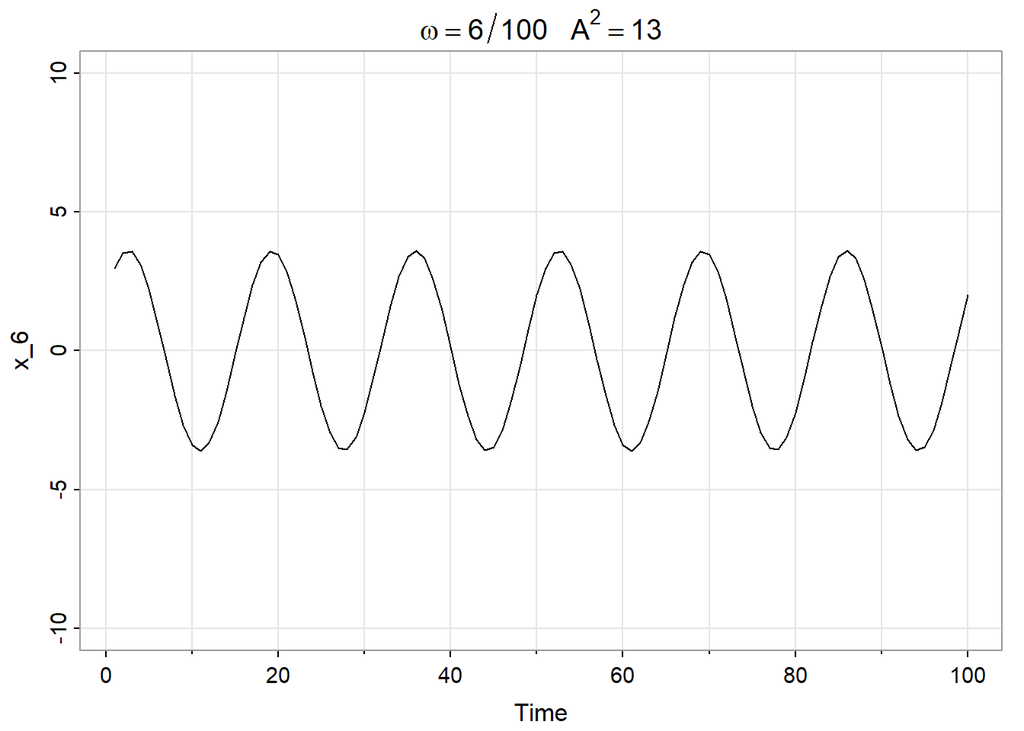

```r
v <- 2*pi*(1:100)/100
x_6 = 2*cos(x = 6*v)  + 3*sin(x = 6*v)
x_10 = 4*cos(x = 10*v) + 5*sin(x = 10*v)
x_40 = 6*cos(x = 40*v) + 7*sin(x = 40*v)
x = x_6 + x_10 + x_40

#par(mfrow=c(2,2))
astsa::tsplot(
  x = x_6,
  ylim = c(-10,10),
  main = expression(
    omega==6/100~~~A^2==13
  )
)
```

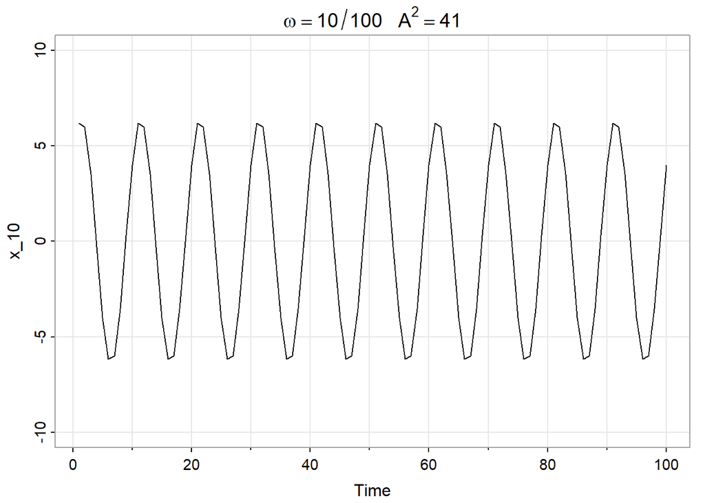

```r
astsa::tsplot(
  x = x_10,
  ylim = c(-10,10),
  main = expression(
    omega==10/100~~~A^2==41
  )
)
```

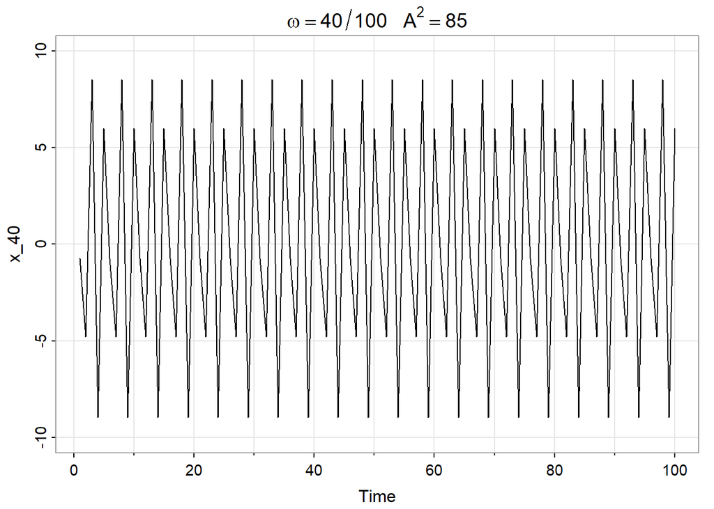

```r
astsa::tsplot(
  x = x_40,
  ylim = c(-10,10),
  main = expression(
    omega==40/100~~~A^2==85
  )
)
```

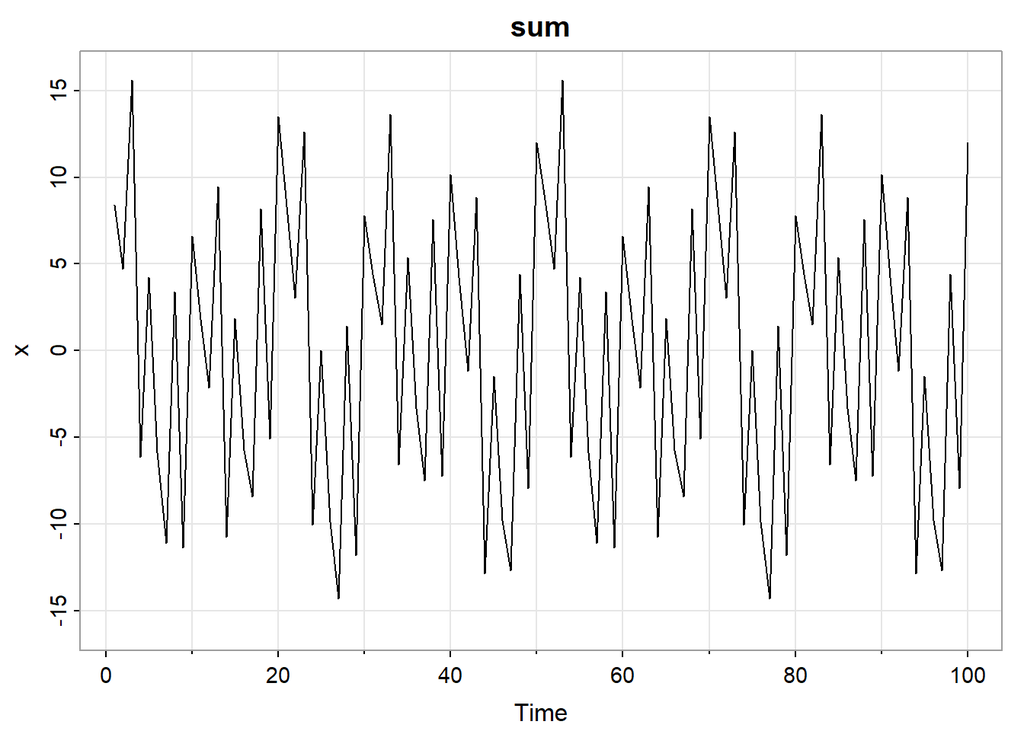

```r
astsa::tsplot(
  x = x,
  ylim = c(-16,16),
  main = "sum"
)
```

Let’s check the approximation we proposed.

```r
var(
  x = x_6
)
```

```
## [1] 6.6
```

```r
2^2 + 3^2
```

```
## [1] 13
```

```r
var(
  x = x_10
)
```

```
## [1] 21
```

```r
4^2 + 5^2
```

```
## [1] 41
```

```r
var(
  x = x_40
)
```

```
## [1] 43
```

```r
6^2 + 7^2
```

```
## [1] 85
```

```r
var(
  x = x
)
```

```
## [1] 70
```

```r
2^2 + 3^2 + 4^2 + 5^2 + 6^2 + 7^2
```

```
## [1] 139
```

#### Example 4.2 Estimation and the Periodogram

When we have a time series sample $x_1,x_2,...,x_n$, and $n$ is odd we can write $x_t$ exactly.

$$x_t = a_0 + \sum_{j = 1}^{(n-1)/2} a_j cos\left(2\pi\dfrac{tj}{n}\right)
+ b_j sin\left(2\pi\dfrac{tj}{n}\right) \\
n \text{ is odd}$$

When $n$ is even, the summation ends at $\dfrac{n}{2} - 1$, and we append the term

$$a_{n/2} cos\left(2\pi \dfrac{t}{2}\right) = a_{n/2} (-1)^t$$

This is exact:

$$x_t = a_0 + \sum_{j = 1}^{(n-1)/2} a_j cos\left(2\pi\dfrac{tj}{n}\right)
+ b_j sin\left(2\pi\dfrac{tj}{n}\right) \\
n \text{ is odd}$$

We think of this as being an approximation to the exact formula.

$$x_t = \sum_{k = 1}^{q}U_{k1}cos(2\pi w_k t) + U_{k2} sin(2\pi \omega_k
t) \\$$

The exact formula can have a lot of coefficients close to zero.

#### Regression coefficients for trigonometric functions

Lemma:

If $n \in \mathbb{Z}.\theta \in \{2\pi j/n|j \in \mathbb{Z},j/n \notin \mathbb{Z}\}$, then

$$\sum_{k = 0}^{n-1} e^{i\theta k} = 0 \\
\sum_{k = 0}^{n-1} cos (\theta k) = 0 \\
\sum_{k = 0}^{n-1} sin (\theta k) = 0$$
Proof:

$$\begin{align}
\sum_{k = 0}^{n-1} e^{i\theta k} =& 1 + e^{i\theta} + e^{i2\theta} +
... + e^{i(n-1)\theta} \\
=& \dfrac{1 - e^{i\theta}}{1 - e^{i\theta}}( 1 + e^{i\theta} +
e^{i2\theta} + ... + e^{i(n-1)\theta}) \\
=& \dfrac{1 - e^{in\theta}}{1 - e^{i\theta}} \\
=& \dfrac{0}{1 - e^{i\theta}}
\end{align}$$

$$\begin{align}
z_{tj} =& cos\left(2\pi \dfrac{j}{n}t\right) \\
\sum_{t = 1}^{n} z_{tj}^2 =& \sum_{t = 1}^{n}cos^2\left(2\pi
j\dfrac{t}{n}\right) \\
=& \sum_{t = 1}^{n}\dfrac{1}{2} + \dfrac{1}{2} cos\left(4\pi
j\dfrac{t}{n}\right) \\
=& \dfrac{n}{2} + \dfrac{1}{2} \sum_{t = 1}^{n}cos\left(4\pi
j\dfrac{t}{n}\right) \\
=& \dfrac{n}{2}
\end{align}$$

$$\begin{align}
z_{tj} =& sin\left(2\pi \dfrac{j}{n}t\right) \\
\sum_{t = 1}^{n} z_{tj}^2 =& \sum_{t = 1}^{n}sin^2\left(2\pi
j\dfrac{t}{n}\right) \\
=& \sum_{t = 1}^{n}\dfrac{1}{2} - \dfrac{1}{2} cos\left(4\pi
j\dfrac{t}{n}\right) \\
=& \dfrac{n}{2} - \dfrac{1}{2} \sum_{t = 1}^{n}cos\left(4\pi
j\dfrac{t}{n}\right) \\
=& \dfrac{n}{2}
\end{align}$$

$$a_0 = \bar{x} \\
a_j = \dfrac{\sum_{t = 1}^{n} x_t cos\left(2\pi
\dfrac{j}{n}t\right)}{\sum_{t = 1}^{n} cos^2\left(2\pi
\dfrac{j}{n}t\right)} = \dfrac{2}{n} \sum_{t = 1}^{n} x_t cos\left(2\pi
\dfrac{j}{n}t\right) \\
b_j = \dfrac{\sum_{t = 1}^{n} x_t sin\left(2\pi
\dfrac{j}{n}t\right)}{\sum_{t = 1}^{n} sin^2\left(2\pi
\dfrac{j}{n}t\right)} = \dfrac{2}{n} \sum_{t = 1}^{n} x_t sin\left(2\pi
\dfrac{j}{n}t\right) \\$$
#### scaled periodogram

We use the scaled periodogram values to indicate magnitude of frequencies.

$$P(j/n) = a_j^2 + b_j^2$$

#### Fourier or fundamental frequencies, $\omega_j = j/n$

The scaled periodogram is the sample variance at each frequency component and estiamtes $\sigma_j^2$ corresponding to the sinusoid oscillating at a frequency of $\omega_j = j/n$.

- Large values of scaled periodogram indicate which frequencies are predominant in the series
- Small values of scaled periodogram may be associated with noise.

Fortunately, it is not necessary to run a large regression to obtain the values of $a_j$ and $b_j$ because they can be computed quickly if $n$ is a highly composite integer.

#### discrete Fourier transform (DFT)

The discrete Fourier transform (DFT) is a complex-valued weighted average of the data given by

$$\begin{align}
d(j/n) &= \dfrac{1}{\sqrt{n}} \sum_{t = 1}^{n} x_t exp(-2\pi
\dfrac{j}{n} t i) \\
&= \dfrac{1}{\sqrt{n}} \sum_{t = 1}^{n} x_t \left(cos\left(2\pi
\dfrac{j}{n} t\right) - i sin\left(2\pi \dfrac{j}{n} t\right)\right) \\
j &= 0,1,2,...,n-1
\end{align}$$

We can compute this using the fast Fourier transform. (Note: different packages and software compute the fast Fourier transform differently; consult the help documentation.)

#### the periodogram

Note:

$$P(j/n) = P(1 - j/n), j = 0,1,2,...,n-1$$

Notice that the variance estimates above match the heights on the periodogram.

Simulate a periodogram, notice that it picked up the components, and reflected the frequencies to $1-j/n$

#### spectral analysis

If we consider the data as a color (waveform) made up of primary colors at various strengths (amplitudes), then we might consider the periodogram as a prism that decomposes the color into its primary colors (spectrum). Hence the term spectral analysis.

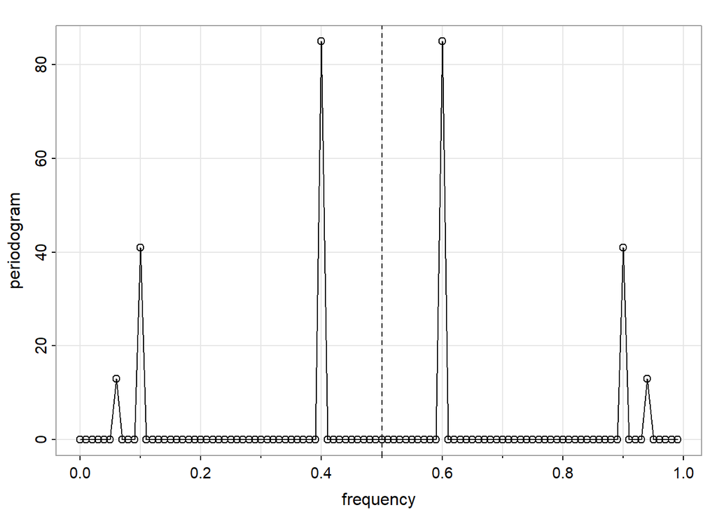

```r
#dev.new()
v_periodogram = abs(
  x = 2*fft(
    z = x
  )/100
)^2
v_frequency = 0:99/100
astsa::tsplot(
  x = v_frequency,
  y = v_periodogram,
  type = "o",
  xlab = "frequency",
  ylab = "periodogram"
)
abline(v=.5, lty=2)
```

Another example

Notice that the periodogram detects the two components close to 0.2

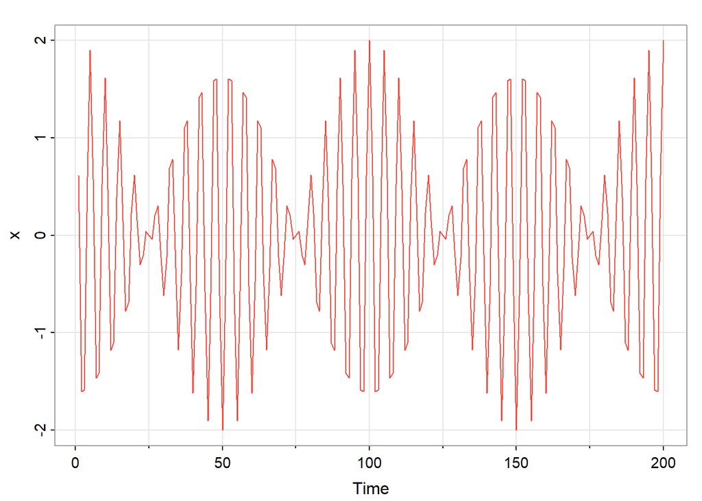

```r
# modulation
t <- 1:200
x <- 2*cos(x = 2*pi*0.2*t) * cos(x = 2*pi*0.01*t) # cos(2*pi*t/10) + cos(2*pi*t*3/10)
astsa::tsplot(
  x = x
)
lines(
  x = cos(x = 2*pi*0.19*t) + cos(x = 2*pi*0.21*t),
  col = 2
)     # the same
```

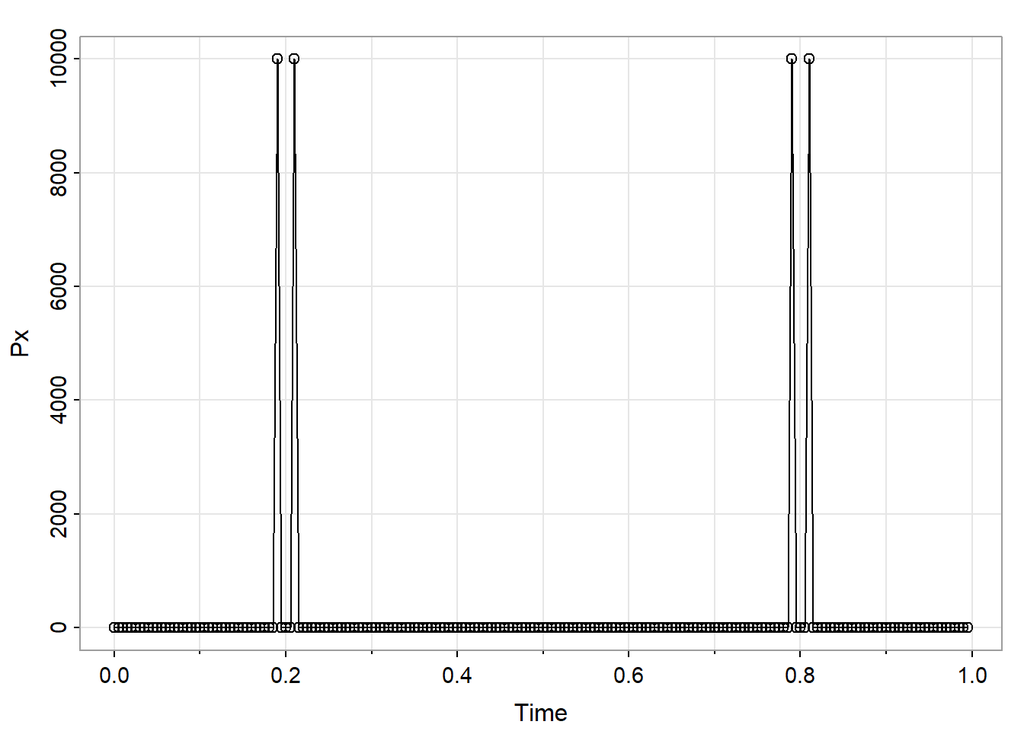

```r
Px = Mod(
  z = fft(
    z = x
  )
)^2
astsa::tsplot(
  x = 0:199/200,
  y = Px,
  type = 'o'
)                   # the periodogram
```

#### Example 4.3 Star Magnitude

The star data in the astsa package are the magnitude of a star taken at midnight for 600 consecutive days. The data are taken from the classic text, The Calculus of Observations, a Treatise on Numerical Mathematics, by E.T. Whittaker and G. Robinson, (1923, Blackie & Son, Ltd.).

The periodogram for frequencies less than 0.08 is also displayed in the figure;

the periodogram ordinates for frequencies higher than 0.08 are essentially zero.

Note that the 29 (≈ 1/0.035) day cycle and the 24 (≈ 1/0.041) day cycle are the most prominent periodic components of the data.

We can interpret this result as we are observing an amplitude modulated signal. For example, suppose we are observing signal-plus-noise,

$$x_t = s_t + v_t \\
s_t = cos(2\pi \omega t) cos(2\pi\delta t) \\
\delta \text{ is very small}$$

In this case, the process will oscillate at frequency $\omega$, but the amplitude will be modulated by $cos(2\pi\delta t)$.

Since

$$2 cos(\alpha) cos(\beta) = cos(\alpha + \beta) + cos(\alpha - \beta) \\
s_t = cos(2\pi \omega t) cos(2\pi\delta t) = \dfrac{cos(2\pi t(\omega +
\delta)) + cos(2\pi t(\omega - \delta))}{2}$$
the periodogram of data generated as will have two peaks close to each other at $\omega \pm \delta$.

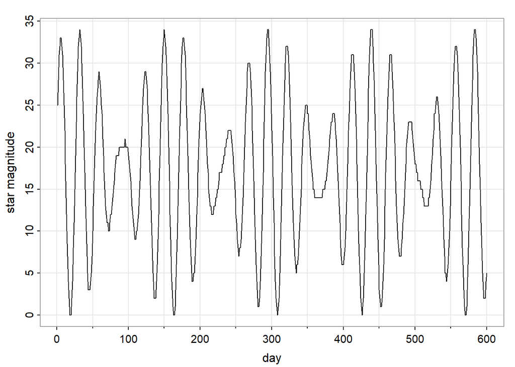

```r
# star mag analysis
data(
  list = "star",
  package = "astsa"
)
length_star = length(
  x = star
)
#par(mfrow=c(2,1))
astsa::tsplot(
  x = star,
  ylab = "star magnitude",
  xlab = "day"
)
```

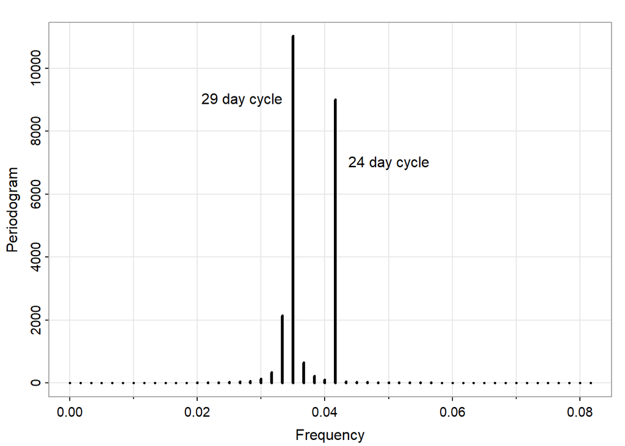

```r
ts_Periodogram = Mod(
  z = fft(
    z = star-mean(x = star)
  )
)^2/length_star
v_Frequency  = (1:length_star -1)/length_star
astsa::tsplot(
  x = v_Frequency[1:50],
  y = ts_Periodogram[1:50],
  type = 'h',
  lwd = 3,
  ylab = "Periodogram",
  xlab = "Frequency"
)
text(
  x = 0.05,
  y = 7000,
  labels = "24 day cycle"
)
text(
  x = 0.027,
  y = 9000,
  labels = "29 day cycle"
)
```

```r
#- a list to help find the peaks
round(
  x = cbind(
    1/v_Frequency[1:30],
    ts_Periodogram[1:30]
  ),
  digits = 3
)
```

```
##       [,1]     [,2]
##  [1,]  Inf     0.00
##  [2,]  600     0.45
##  [3,]  300     0.64
##  [4,]  200     0.65
##  [5,]  150     0.96
##  [6,]  120     1.10
##  [7,]  100     1.57
##  [8,]   86     1.92
##  [9,]   75     2.66
## [10,]   67     3.36
## [11,]   60     4.60
## [12,]   55     6.00
## [13,]   50     8.30
## [14,]   46    11.30
```

[output cut: 16 more lines]